# Bagging and Random Forests

## Where we left off

- **Day 16:** prune a tree to the size CV picks (one-SE rule).
  - Back to the student debt: the one-SE rule keeps 5 leaves, CV error 18.2%.
  - Easy to read, but **unstable**: new data, new tree.
- **Today:**
  - Where the resamples come from: the **bootstrap**.
  - **Bagging**: many trees vote.
  - **Random forests**: make the trees disagree on purpose.

## One data set, many training sets

> **We have one set of 2,000 students. How can we get a second, third, … training set?**
- **Bootstrap sample:** draw 2,000 students **with replacement** from the 2,000.
  - Some students are drawn twice or more, some not at all.

[output not shown]

- A student is left out of one draw with probability \(1 - \frac{1}{n}\). In at least once: \(1 - \left(1 - \frac{1}{n}\right)^n = 0.632\): about **two-thirds** of the students (here 1,255).

## Same method, different trees

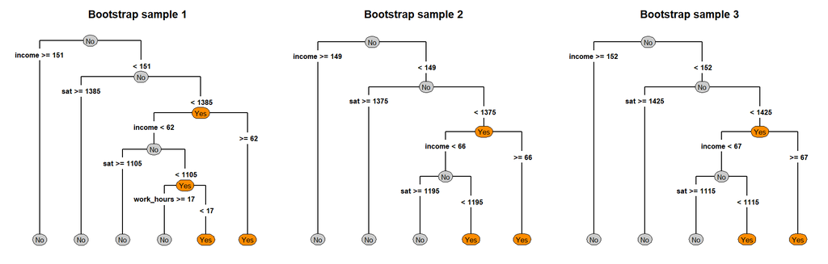

## Bagging: let the trees vote

**B**ootstrap **agg**regat**ing** (ISL 8.2.1):

- Draw \(B\) bootstrap samples (say \(B\) = 500).
- Grow a **full** tree on each: low bias, high variance.
- Predict a new student: each tree votes Yes or No; the **majority** wins.
- CV error: full tree 23.8% → bagging **16.4%**.

## Why averaging helps

> **Each full tree is noisy. Why is the vote of 500 less noisy?**
- Day 9: a full tree has low bias but **high variance**. Averaging leaves the bias alone and attacks the variance.
- Average \(B\) predictions, each with variance \(\sigma^2\):
  - **Independent:** the average has variance \(\sigma^2 / B\), which goes to 0 as \(B\) grows.
  - **Correlated** (correlation \(\rho\) between any two): \(\rho\,\sigma^2 + (1-\rho)\,\sigma^2 / B\).
- More trees shrink only the second term. **\(\rho\,\sigma^2\) is a floor**: the more alike the trees, the less averaging can help.

## Out-of-bag error: CV for free

- Each tree never saw about **one-third** of the students: its **out-of-bag (OOB)** students.
- For each student:
  - collect the votes of only the trees that **didn’t** train on them (about 184 of 500),
  - compare that vote with the truth.
- **OOB error** = error rate of those votes over all 2,000 students.
  - Every prediction comes from trees that never saw the student, like a test set.
  - No folds, no refitting: it comes with the forest.
- Bagging: OOB error 15.6%, 5-fold CV error 16.4%. Close.

## How many trees?

> **Does adding more trees ever hurt?**

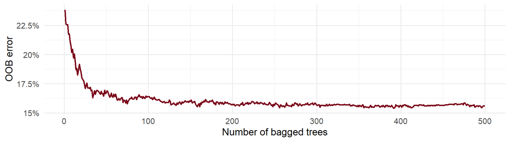

- Error falls quickly, then **levels off** at the floor. Each new tree is one more vote on its own bootstrap sample; it can’t fit the training data more closely.
- More trees **don’t overfit**. They only cost computing time.

## The trouble with bagging

> **First question of each of the 500 bagged trees:**

| First question | Trees | Share |
| --- | --- | --- |
| income | 492 | 98.4% |
| sat | 8 | 1.6% |

- `income` is so much better than anything else that almost every tree starts with it.
- The trees look alike, so they make the **same mistakes**: on held-out students, two bagged trees’ votes have correlation \(\rho \approx\) 0.44. That sets the floor.

## Random forests: decorrelate the trees

> **How do we stop every tree from starting with `income`?**
- Same as bagging, plus one change (ISL 8.2.2): **at each split, the tree may only choose from a few predictors, drawn at random.**
  - Say 3 of the 10: a new draw at every split.
- Often `income` isn’t among them, so the tree has to use something else.
  - First question: `income` in 30% of the trees (bagging: 98%).
- Back to the vote’s variance, \(\rho\,\sigma^2 + (1-\rho)\,\sigma^2 / B\):
  - Each tree is a bit worse (higher \(\sigma^2\)), but the trees are less alike (lower \(\rho\)): a lower floor.
- How many to draw is a **tuning parameter**. R calls it **`mtry`**.
  - `mtry` = all 10 → bagging. Default: \(\sqrt{p}\) rounded down = 3.

## Choosing `mtry`

> **OOB error, 500 trees each.** Which `mtry` would you pick?

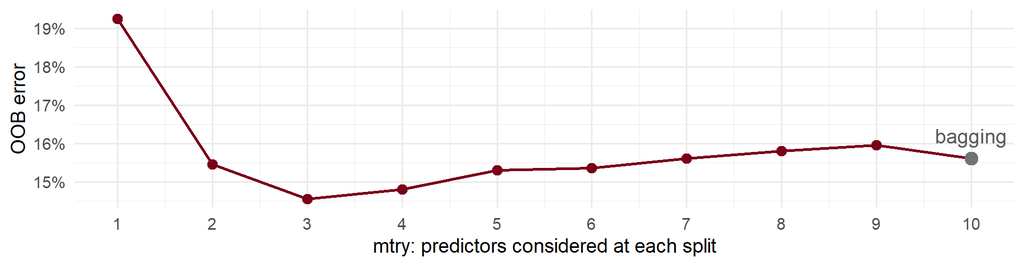

- Lowest at `mtry` = 3 (14.5%), the default; bagging 15.6%.
- OOB error makes this cheap to tune: no CV loop.

## Why not `mtry` = 1?

> **Held-out students (one fold), 500 trees each.**

| mtry | Correlation between two trees, ρ | Error of one tree | Error of the vote |
| --- | --- | --- | --- |
| 10 (bagging) | 0.44 | 22.7% | 15.5% |
| 3 | 0.32 | 25.4% | 14.5% |
| 1 | 0.14 | 30.0% | 18.2% |

- Fewer predictors per split → less alike trees (lower \(\rho\)), but each tree is worse (higher \(\sigma^2\)).
- `mtry` = 1: nearly uncorrelated trees, but each one is worse than predicting “No” for everyone (27.5% on this fold). Their vote still gets 18.2%.
- The best `mtry` balances the two.

## Which predictors matter?

> **A forest has 500 trees. Which columns is it using?**

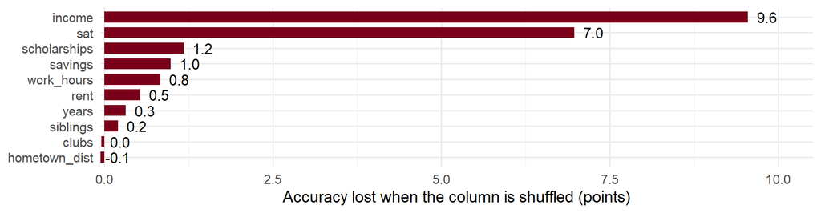

- **Variable importance:** shuffle one column among the OOB students and see how much worse the forest gets.
- `income` and `sat` carry the staircase. The unrelated columns (`hometown_dist`, `clubs`) score about 0.

## What we gave up

> **Same two predictors (income, SAT): one tree vs a forest.**

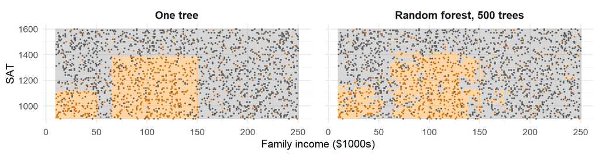

- The forest follows the data more closely, but there’s **no tree to read**: “why was this student flagged?” has 500 answers.
- Importance says **which** columns matter, not **how**.

## Did it work?

> **Same 5 folds as Days 15–16, all 10 predictors.** CV error rate (lower is better).

| Model | CV error |
| --- | --- |
| Logistic regression | 22.8% (SE 0.6) |
| KNN, K = 25 | 21.8% (SE 0.6) |
| Full tree | 23.8% (SE 1.3) |
| Pruned tree, 5 leaves (one-SE rule) | 18.2% (SE 0.9) |
| Bagging, 500 trees | 16.4% (SE 0.5) |
| **Random forest, 500 trees, `mtry` = 3** | **15.0% (SE 0.6)** |

- Bagging beats every single tree; the random forest beats bagging. Both gaps are more than one SE.
- The price: no tree to read.

## In R

```r
library(randomForest)
forest <- randomForest(heavy_debt ~ ., data = students,
                       ntree = 500,          # number of trees
                       mtry = 3,             # predictors per split (10 = bagging)
                       importance = TRUE)    # also measure variable importance
forest$err.rate[500, "OOB"]                  # OOB error after all 500 trees
predict(forest, new_students)                # majority vote
importance(forest, type = 1, scale = FALSE)  # accuracy lost when shuffled
```

- The outcome must be a **factor** (Yes/No) for a classification forest.
- No pruning: forests use full trees and let the vote handle the variance.

## Summary

- **Bootstrap:** resample \(n\) rows with replacement; about two-thirds of the rows each time.
- **Bagging:** a full tree on each bootstrap sample, majority vote. Lowers variance.
- **OOB error:** each row predicted by the trees that didn’t see it. A free test error.
- **Random forest:** bagging + only `mtry` random predictors per split. Decorrelated trees, a better vote.
- More trees never overfit. Choose `mtry` with OOB error.
- **Variable importance** replaces reading the tree.
- **Day 18:** boosting, which grows trees **one after another**.

## For rest of class

- Work on the `day17_activity`
  - new data: Boston suburbs (`Boston`, ISLR2). Is a suburb’s crime rate above the median?
  - compare logistic regression, one tree, bagging, and a random forest: which do better, why, and by how much?
  - choose `mtry` with OOB error, then score all four methods with repeated CV
- Ask me questions if you run into issues